# Phylogenetic Mixed Models

Madison Bradley-Cronkwright (mmb103@duke.edu)

2024

### **Session Set-up**

When working in RStudio, it’s good practice to first clear the global environment and set a working directory.

```r
rm(list=ls(all=T)) # good practice to first clear workspace

# set working directory
## modify to pathway of the folder where your data is saved
setwd("C:/Users/mads/Desktop/Summer 2024/Doug's stats course materials/Markdowns/Phylogenetic Mixed Models")
```

### **Import Data**

Import data saved in the working directory in CSV format, then use the str() function to determine the structure of the dataset.

```r
# import data in csv format
## modify to name of your data sheet
data<-read.csv("C:/Users/mads/Desktop/Summer 2024/Doug's stats course materials/Markdowns/Phylogenetic Mixed Models/data_files/PMM_dataset_2.csv",header = TRUE, stringsAsFactors = TRUE,fileEncoding = "UTF-8-BOM")

# good practice to check imported data for its structure
str(data)
```

```
'data.frame':   77 obs. of  17 variables:
 $ Order                 : Factor w/ 11 levels "Artiodactyla",..: 10 9 10 10 2 6 1 9 2 1 ...
 $ Species               : Factor w/ 77 levels "Alouatta_sara",..: 15 1 2 3 4 5 6 7 8 9 ...
 $ Habitat               : Factor w/ 3 levels "Arid","Temperate",..: 3 3 2 2 3 2 2 3 2 2 ...
 $ Body_mass_g           : num  5460 4400 25 18.3 10300 ...
 $ Brain_mass_g          : Factor w/ 75 levels "0.14504","0.173033708",..: 45 62 15 11 63 6 49 66 29 23 ...
 $ Heart_mass_g          : num  17.57 24 0.182 0.135 75.185 ...
 $ Lungs_mass_g          : Factor w/ 74 levels "0.07","0.143",..: 58 61 11 8 45 9 64 56 72 49 ...
 $ Kidneys_mass_g        : num  22.17 9.86 0.34 0.26 51.33 ...
 $ Liver_mass_g          : num  140.13 81.21 0.988 1.095 915.18 ...
 $ Digestive_tract_mass_g: num  110.31 113.35 1.34 1.2 239.7 ...
 $ Stomach_mass_g        : Factor w/ 65 levels "0.068","0.08",..: 36 49 12 9 63 4 65 25 48 59 ...
 $ Intestine_mass_g      : Factor w/ 67 levels "0.2344","0.286",..: 66 60 16 14 32 1 67 64 48 43 ...
 $ Spleen_mass_g         : Factor w/ 68 levels "0.005","0.01",..: 63 62 9 8 46 14 61 26 41 35 ...
 $ Visc_mass_g           : num  369.95 338.68 3.89 3.56 1602.71 ...
 $ BMR                   : num  2364.9 2000.3 42.4 55.9 1128.1 ...
 $ body_temperature      : num  NA NA 36.7 36.7 36.7 38.3 38.4 NA 40 NA ...
 $ diet                  : Factor w/ 4 levels "browsing/grazing",..: 3 1 3 3 2 4 1 3 2 1 ...
```

### **Install or Load packages**

Use install.packages() function if the package needs to be installed. If install.packages() fails, it may be easier to download packages according to instructions from their github.

It may also be helpful to open R session as an Administrator to prevent package installation issues.

```r
# load in packages
library(rethinking)
library(dagitty)
library(ggpmisc)
library(phytools)
library(ggplot2)
library(tidyverse)
library(ggtree)
rstan_options(javascript = FALSE)
```

### **Making a Least-Squares Consensus Tree from a set of trees**

Here, I make a tree for analysis from a set of 100 tip-dated maximum credibility trees from a 10000 tree sample (http://vertlife.org/phylosubsets/)

If you already have a single tree for your analysis made elsewhere, you can skip to next chunk.

```r
# load in 100 tip-dated maximum clade credibility trees (from a 10000 tree sample)
my.trees<-read.nexus("C:/Users/mads/Desktop/Summer 2024/Doug's stats course materials/Markdowns/Phylogenetic Mixed Models/data_files/tip_dated_output.nex") # produces a multiPhylo object

# make least-squares consensus tree (Lapointe & Cucumel, 1997) from a set of input trees
tree<-ls.consensus(my.trees, check.labels=TRUE, rooted=TRUE,start=NULL, tol=1e-12, quiet=FALSE) # can set a "start" tree for the function to work from

# save the LS consensus tree to wd
writeNexus(tree,file = "LS_cons_tree")
```

### **Import Phylogenetic Tree**

```r
# load tree in NEXUS format
tree<-read.nexus("LS_cons_tree")
```

[figure not shown]

```r
# plot LS consensus tree
plot(tree, type = "phylogram", use.edge.length = T, show.tip.label = TRUE,node.depth=2)

plotTree(root(tree,outgroup="Didelphis_virginiana"))

ggtree(tree) + geom_tiplab(as_ylab=TRUE, color='firebrick')
ggtree(tree, layout="circular") + geom_tiplab(aes(angle=angle))
```

### **Compute implied co-variance matrix as a parameter for models**

```r
spp_obs <- as.character(data$Species)
tree_trimmed <- keep.tip(tree,spp_obs) # trim tree to tips, indexed by species labels from the original data set
Dmat <- cophenetic(tree_trimmed) # distance matrix
Rbm <- corBrownian(phy=tree_trimmed)
V <- vcv(Rbm) # computes expected variance and covariance of continuous trait

# Warning message; this is a signal that the data further down the line needs to be in the same order as in the tree file
```

### **Data Prep for Models**

To use ulam for models, data should be in a list instead of a data frame. In general, it is easier to build models with reasonable and regularized priors without first interrogating the data (blind priors) by converting all continuous variables to z-scores.

Here, 3 data lists are built for examples of models with different desired outputs.

| Data List Name | Description | Usage |
| --- | --- | --- |
| dat_list_1 | all variables, with data cropped to rows with complete cases of TM variable | models directly measuring relationships between TM and other variables |
| dat_list_2 | TM variable not included in list, no rows are cropped from data | models that do not include TM |
| dat_list_3 | all variables, no rows are cropped. Missing TM values are included as ‘na’ | models that can impute missing TM values |

```r
colnames(data)<-c("order","species","habitat","body_mass","brain_mass","heart_mass","lung_mass","kidney_mass","liver_mass","total_GI_mass","stomach_mass","intestine_mass","spleen_mass","visc_mass","BMR","body_temp","diet") # variables renamed to remove units and capitalized letters; just easier for script writing, but not required

# calculate somatic mass variable
data$somatic_mass<-data$body_mass-data$visc_mass

# calculate proportion visc. mass variable
data$prop_visc_mass<-data$visc_mass/data$body_mass

# log continuous data
data$log_body_mass<-log(data$body_mass)
data$log_BMR<-log(data$BMR)
data$log_visc_mass<-log(data$visc_mass)
data$log_som_mass<-log(data$somatic_mass)
data$log_prop_visc_mass<-log(data$prop_visc_mass)

# convert data from data frame to data lists for feeding to models
# data for each continuous variable is standardized to z-scores

# data list with complete cases for TM, used for directly measuring relationships with TM and plotting
d.complete<-data[ complete.cases( data$body_temp) , ]
dat_list_1 <- list(
  N_spp = nrow(d.complete),
  BM = standardize(d.complete$log_body_mass),
  VM = standardize(d.complete$log_visc_mass),
  SM = standardize(d.complete$log_som_mass),
  H = coerce_index(d.complete$habitat),
  D = coerce_index(d.complete$diet),
  O = coerce_index(d.complete$order),
  BMR = standardize(d.complete$log_BMR),
  TM = standardize(d.complete$body_temp),
  Imat = diag(nrow(d.complete)))

# data list with no TM, use for models without TM
dat_list_2 <- list(
  N_spp = nrow(data),
  BM = standardize(data$log_body_mass),
  VM = standardize(data$log_visc_mass),
  SM = standardize(data$log_som_mass),
  prop_VM = standardize(data$prop_visc_mass),
  prop_VM_raw = data$prop_visc_mass,
  species = data$spp_obs,
  H = coerce_index(data$habitat),
  D = coerce_index(data$diet),
  O = coerce_index(data$order),
  BMR = standardize(data$log_BMR),
  Imat = diag(nrow(data)))

# data list of all variables, na for missing TM values, use for imputing TM
dat_list_3 <- list(
  N_spp = nrow(data),
  BM = standardize(data$log_body_mass),
  VM = standardize(data$log_visc_mass),
  SM = standardize(data$log_som_mass),
  prop_VM = standardize(data$prop_visc_mass),
  TM = standardize(data$body_temp),
  species = data$spp_obs,
  H = coerce_index(data$habitat),
  D = coerce_index(data$diet),
  O = coerce_index(data$order),
  BMR = standardize(data$log_BMR),
  Imat = diag(nrow(data)) )
```

### **To make phylogenetic regressions, add scaled and reordered phylogenetic distance matrix to all the data lists**

```r
# dat_list_1
spp_obs2<-as.character(d.complete$species) # need to first re-trim tree to only have tips that have TM values
tree_trimmed2 <- keep.tip(tree,spp_obs2)
Rbm2 <- corBrownian(phy=tree_trimmed2)
V2 <- vcv(Rbm2)
dat_list_1$V2 <- V2[spp_obs2,spp_obs2]
dat_list_1$R2 <- dat_list_1$V2/max(V2)
dat_list_1$R2 <- dat_list_1$V2/max(V2)
Dmat2 <- cophenetic(tree_trimmed2)
dat_list_1$Dmat2 <- Dmat[spp_obs2,spp_obs2]/max(Dmat2)

# dat_list_2
dat_list_2$V <- V[spp_obs,spp_obs]
# convert to correlation matrix
dat_list_2$R <- dat_list_2$V/max(V)
dat_list_2$Dmat <- Dmat[spp_obs,spp_obs]/max(Dmat)

# dat_list_3
# put species in right order (should already be in correct order, but this is good practice)
dat_list_3$V <- V[spp_obs,spp_obs]
# convert to correlation matrix
dat_list_3$R <- dat_list_3$V/max(V)
dat_list_3$Dmat <- Dmat[spp_obs,spp_obs]/max(Dmat)
```

### **Phylogenetic Mixed Model with one continuous predictor and one continuous outcome**

Example of one of the simplest cases of using Bayes to model the relatioship between two continuous variables while including phylogenetic distance as an additional predictor parameter.

Model 7 in Model Notation Index

m.tm_bmr.p: phylo of BMR~TM

```r
# Model 7 in Model Notation Index
m.tm_bmr.p<-ulam(
  alist(
    BMR~multi_normal(mu,SIGMA),
    mu<-a+b_TM*TM,
    matrix[N_spp,N_spp]: SIGMA <- cov_GPL1(Dmat2, etasq , rhosq , 0.01 ),
    a ~ normal(0,0.5),
    b_TM ~ normal(0,0.5),
    etasq ~ half_normal(1,0.25),
    rhosq ~ half_normal(3,0.25)
  ), data = dat_list_1, chains=2
)
```

```r
traceplot(m.tm_bmr.p)
```

```
## [1] 1000
## [1] 1
## [1] 1000
```

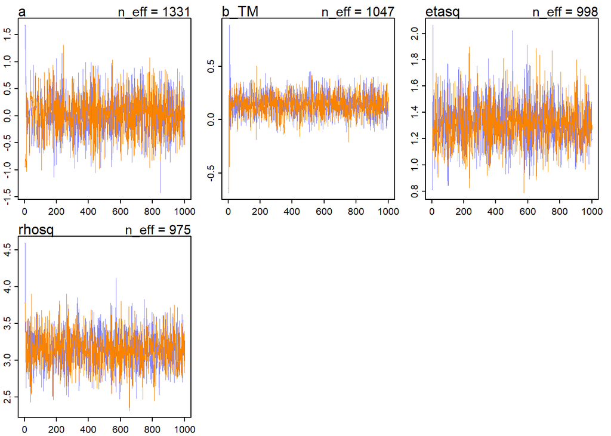

```r
par(mfrow = c(1, 1))
```

```r
precis(m.tm_bmr.p,depth=2)
```

```
##            mean        sd        5.5%     94.5%     n_eff
## a     0.0251622 0.3616923 -0.56692602 0.6001261 1330.9271
## b_TM  0.1522868 0.1096854 -0.02344752 0.3267431 1046.8787
## etasq 1.3087479 0.1604161  1.06374068 1.5668888  997.9622
## rhosq 3.1454403 0.2441534  2.75768886 3.5241635  974.6018
##           Rhat4
## a     1.0018617
## b_TM  0.9994232
## etasq 1.0005147
## rhosq 1.0026468
```

### **Phylogenetic Mixed Model with multiple predictors and continuous outcome**

Vm, sm, and H as predictor, as a phylo regression Model 8.2 in Model Notation Index

BMR outcome, a indexed by habitat, VM and SM each as a predictor, with phylo [model 8.2]

```r
# Vm, sm, and H as predictor, as a phylo regression
# Model 8.2 in Model Notation Index
m9.change.h.p<-ulam(
  alist(
    BMR~multi_normal(mu,SIGMA),
    mu<-a[H]+b_VM*VM+b_SM*SM,
    matrix[N_spp,N_spp]: SIGMA <- cov_GPL1(Dmat, etasq , rhosq , 0.01 ),
    a[H] ~ dnorm(0,0.5),
    b_VM ~dnorm(0,0.5),
    b_SM ~dnorm(0,0.5),
    etasq ~ half_normal(1,0.25),
    rhosq ~ half_normal(3,0.25)
  ), data = dat_list_2, chains=2
)
```

```r
traceplot(m9.change.h.p)
```

```
## [1] 1000
## [1] 1
## [1] 1000
```

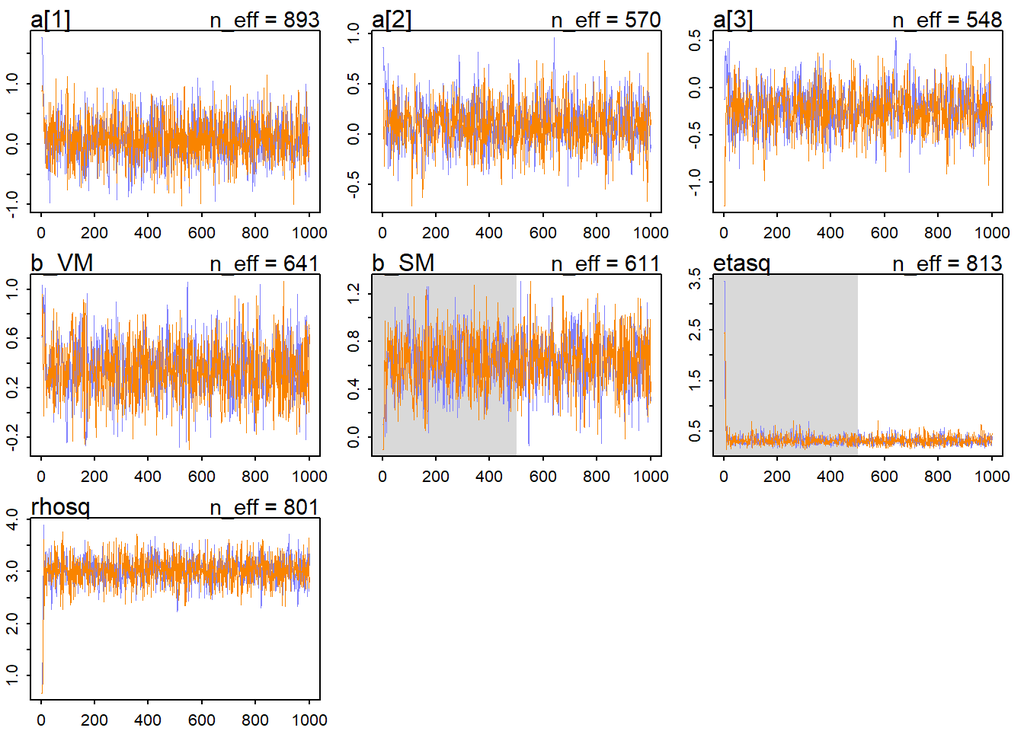

```r
par(mfrow = c(1, 1))
```

```r
precis(m9.change.h.p,depth=2)
```

```
##              mean         sd         5.5%     94.5%
## a[1]   0.08737432 0.35105622 -0.460088693 0.6701781
## a[2]   0.10485655 0.21980969 -0.252083213 0.4506739
## a[3]  -0.22496708 0.21856209 -0.579436870 0.1230929
## b_VM   0.34167814 0.22281085  0.002546905 0.7051099
## b_SM   0.63960150 0.22211670  0.292392628 0.9747238
## etasq  0.32963125 0.08438982  0.211748058 0.4831146
## rhosq  3.02077171 0.25023121  2.615020169 3.4104542
##          n_eff     Rhat4
## a[1]  893.3101 0.9999352
## a[2]  570.4937 1.0047446
## a[3]  547.6506 1.0057606
## b_VM  641.3986 1.0001121
## b_SM  611.2337 1.0007552
## etasq 813.1678 1.0000935
## rhosq 801.2219 0.9989288
```

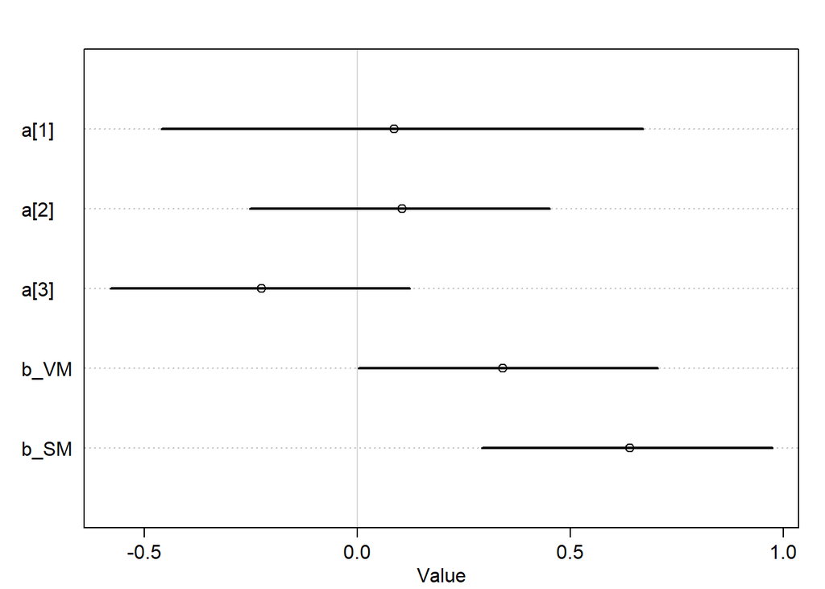

```r
plot(precis(m9.change.h.p,pars=c("a[1]","a[2]","a[3]","b_VM","b_SM"),depth = 2))
```

### **Phylogenetic Mixed Model with multiple predictors and continuous outcome that imputes missing continuous values**

Vm, sm, tm and H as predictor, as a multiregression, TM imputed Model 8.4 in the model notation index

bmr outcome, vm, sm, tm and H as predictor, as a multiregression, TM imputed, phylo version [model 8.4]

```r
# Vm, sm, tm and H as predictor, as a multiregression, TM imputed
# Model 8.4 in the model notation index
m7.p<-ulam(
  alist(
    BMR~multi_normal(mu,SIGMA),
    mu<-a[H]+b_VM*VM+b_SM*SM+b_TM*TM,
    matrix[N_spp,N_spp]: SIGMA <- cov_GPL1(Dmat, etasq , rhosq , 0.01 ),
    TM~dnorm(nu,sigma_TM), # add to impute missing temp data
    a[H] ~ dnorm(0,0.5),
    nu ~ dnorm(0,0.5),
    b_VM ~dnorm(0,0.5),
    b_SM ~dnorm(0,0.5),
    b_TM~dnorm(0,0.5),
    sigma_TM~dexp(1),
    etasq ~ half_normal(1,0.25),
    rhosq ~ half_normal(3,0.25)
  ), data = dat_list_3, chains=2
)
```

```
## Found 26 NA values in TM and attempting imputation.
```

```
## [1] 1000
## [1] 1
## [1] 1000
```

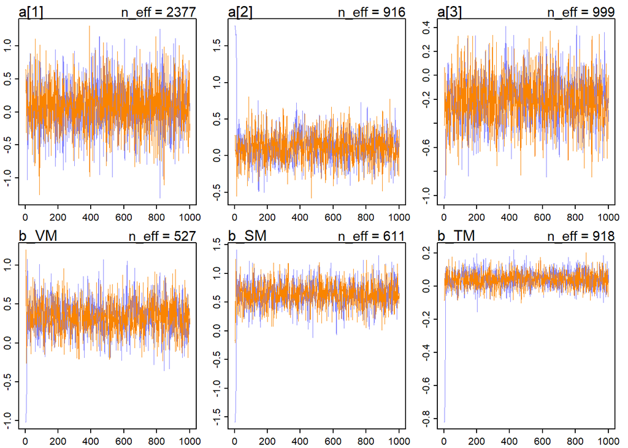

```r
traceplot(m7.p,pars=c("a[1]","a[2]","a[3]","b_VM","b_SM","b_TM"))
```

```r
par(mfrow = c(1, 1))
precis(m7.p,depth=2)
```

```
##                       mean         sd         5.5%
## a[1]           0.084251182 0.37921785 -0.546134246
## a[2]           0.114923516 0.20175530 -0.224559487
## a[3]          -0.210892282 0.20224885 -0.538063079
## nu             0.017442836 0.13708185 -0.200824213
## b_VM           0.332516700 0.21841550 -0.008434998
## b_SM           0.639649774 0.21269135  0.290024271
## b_TM           0.043805530 0.04805217 -0.034265406
## sigma_TM       1.013202422 0.09772885  0.868533250
## etasq          0.321940510 0.08075384  0.207493801
## rhosq          3.020964175 0.25000149  2.636340371
## TM_impute[1]   0.139731324 1.06044823 -1.605281877
## TM_impute[2]   0.114221613 0.99543964 -1.427193361
## TM_impute[3]  -0.159111633 0.96661374 -1.663700708
## TM_impute[4]   0.084213736 0.95626981 -1.465264582
## TM_impute[5]  -0.367223382 1.15178286 -2.197553993
## TM_impute[6]   0.081859399 1.01265798 -1.506413214
## TM_impute[7]  -0.032283432 0.97473005 -1.539391892
## TM_impute[8]   0.145926657 1.05482839 -1.572445998
## TM_impute[9]  -0.046999284 1.05613976 -1.741448375
## TM_impute[10] -0.011094118 0.96740263 -1.594095931
## TM_impute[11]  0.224968865 1.05875070 -1.440411565
## TM_impute[12]  0.064469637 0.98761787 -1.451976591
## TM_impute[13] -0.137266279 1.04831911 -1.828555980
## TM_impute[14]  0.335200707 1.00717869 -1.256798966
## TM_impute[15]  0.002827484 1.01748888 -1.566344620
## TM_impute[16] -0.042717662 1.05154913 -1.783125384
## TM_impute[17] -0.169219429 0.97165435 -1.731982599
## TM_impute[18]  0.324204319 1.02279917 -1.274117542
## TM_impute[19]  0.321573050 0.97649750 -1.195034211
## TM_impute[20]  0.112324477 0.97269923 -1.399741258
## TM_impute[21]  0.171072020 1.03727526 -1.407602716
## TM_impute[22] -0.057957647 1.01751235 -1.615380541
## TM_impute[23]  0.064474157 1.03077703 -1.567365071
## TM_impute[24]  0.069969490 1.05288020 -1.629777837
## TM_impute[25]  0.034628174 1.00048358 -1.585741410
## TM_impute[26] -0.026060096 1.00605612 -1.661023501
##                   94.5%     n_eff     Rhat4
## a[1]          0.6912425 2377.0945 0.9983718
## a[2]          0.4285272  915.9060 0.9983807
```

[output cut: 19 more lines]

```
## TM_impute[12] 1.6030901 2235.3374 0.9982992
## TM_impute[13] 1.5401939 1599.6602 1.0001564
## TM_impute[14] 1.8958092 1549.5969 0.9996295
## TM_impute[15] 1.6453719 2188.6568 1.0000268
## TM_impute[16] 1.6094476 1657.7368 1.0019901
## TM_impute[17] 1.3969669 2183.6710 0.9986823
## TM_impute[18] 1.9394298 1387.2252 1.0008413
## TM_impute[19] 1.8431296 1609.7638 0.9989866
## TM_impute[20] 1.6419802 2076.1620 1.0005537
## TM_impute[21] 1.8575194 1654.7414 1.0000088
## TM_impute[22] 1.5357787 1607.7814 0.9998064
## TM_impute[23] 1.6425253 2429.9296 0.9989356
## TM_impute[24] 1.6897588 2425.0407 0.9988953
## TM_impute[25] 1.6043082 1793.8942 0.9983041
## TM_impute[26] 1.5642110 1962.4671 0.9984756
```

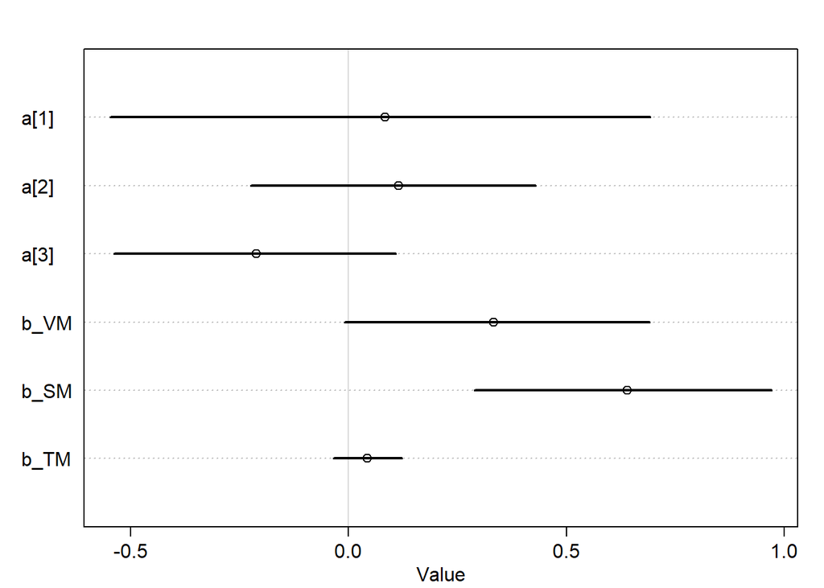

```r
plot(precis(m7.p,pars=c("a[1]","a[2]","a[3]","b_VM","b_SM","b_TM"),depth = 2))
```

### **Save the models to an RData file in the working directory**

This chunk saves the model as an RData object to the working directory so that it can be imported without having to run the model every session.

```r
# save
save(m7.p,m9.change.h.p,m.tm_bmr.p,file = "BMR_models.RData")
```

### **Load the models into environment**

```r
load(file = "BMR_models.RData")
```

### **Plot the model’s estimate of the phylogenetic effect in the predictive model**

The effect of phylogenetic distance on BMR, represented as the prior predictions of the OU process kernel and as samples from the posterior of the preferred predictive model.

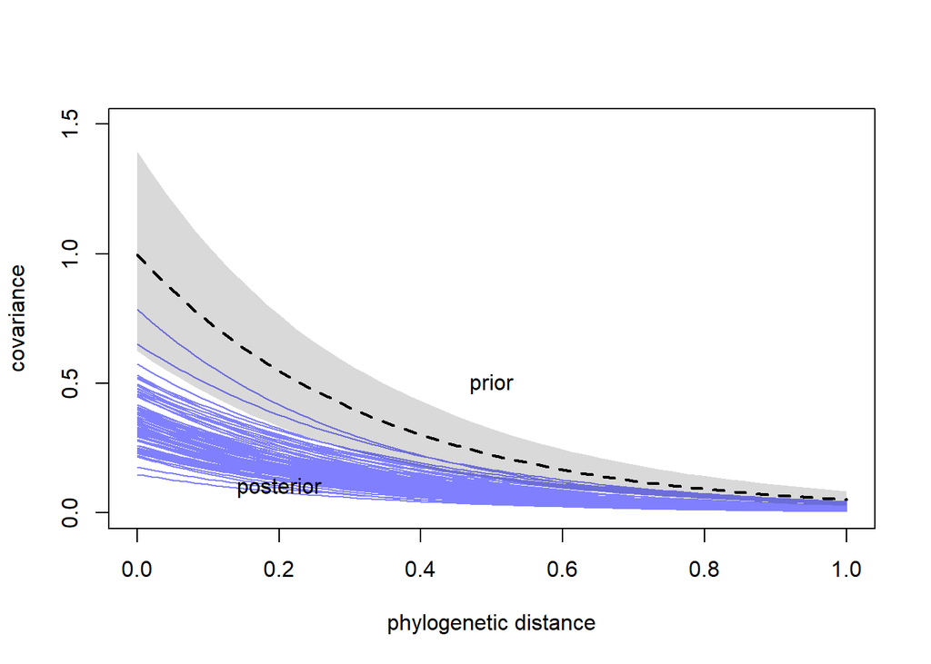

```r
# plot effect of phylo in predictive model
post <- extract.samples(m9.change.h.p)
plot( NULL , xlim=c(0,max(dat_list_3$Dmat)) , ylim=c(0,1.5) ,
xlab="phylogenetic distance" , ylab="covariance" )
# posterior
for ( i in 1:77 )
curve( post$etasq[i]*exp(-post$rhosq[i]*x) , add=TRUE , col=rangi2 )
# prior mean and 89% interval
eta <- abs(rnorm(1e3,1,0.25))
rho <- abs(rnorm(1e3,3,0.25))
d_seq <- seq(from=0,to=1,length.out=50)
K <- sapply( d_seq , function(x) eta*exp(-rho*x) )
lines( d_seq , colMeans(K) , lwd=2,lty=2 )
shade( apply(K,2,PI) , d_seq )
text( 0.5 , 0.5 , "prior" )
text( 0.2 , 0.1 , "posterior" )
```

### **References**

*rethinking*:McElreath, R (2019). rethinking: Statistical Rethinking book package. R package version 1.93.

McElreath, R. (2020). Statistical rethinking: A Bayesian course with examples in R and Stan. CRC press.

*VertLife Phylosubsets*: vertlife.org/phylosubsets/

*VertLife*: Upham, Nathan S.; Esselstyn, Jacob A.; Jetz, Walter (2019), Inferring the mammal tree: Species-level sets of phylogenies for questions in ecology, evolution, and conservation, v4, Dataset, https://doi.org/10.5061/dryad.tb03d03

OS: Windows 10 x64 OS Build: 22631.3737 R Version: 4.1.1 Platform: x86_64-w64-mingw32/x64 (64-bit)